# replication

Nick F & Aaron K

February 24, 2015

# Study 1a

> In this study, there were 103 participants (mean age = 29.3 years; 44 females, 59 males; median household size = 3 people; median household income = $35,000)…One participant was excluded as an outlier on income (more than 3 SD from the mean).

```
##   average_age
## 1        29.3
```

```
## Source: local data frame [2 x 2]
##
##   V4 sex_breakdown
## 1  f            44
## 2  m            59
```

```
##   sample.size median.household.income median.household.size
## 1         103                   35000                     3
```

## *Results*

> We conducted binary logistic regressions to compare how frequently partici- pants cited each of the two considerations of interest (trade-offs vs. location) as a function of income. Higher-income participants were more likely than lower-income participants to name location as the main consideration, β = 2.52, Wald-test χ2(1, N = 102) = 5.54, p < .05,

```
##
## Call:
## glm(formula = location ~ logses, family = "binomial", data = clean_1a)
##
## Deviance Residuals:
##     Min       1Q   Median       3Q      Max
## -1.0494  -0.7104  -0.5302  -0.3656   2.4029
##
## Coefficients:
##             Estimate Std. Error z value Pr(>|z|)
## (Intercept)  -12.597      4.814  -2.617  0.00888 **
## logses         2.521      1.071   2.353  0.01860 *
## ---
## Signif. codes:  0 '***' 0.001 '**' 0.01 '*' 0.05 '.' 0.1 ' ' 1
##
## (Dispersion parameter for binomial family taken to be 1)
##
##     Null deviance: 100.963  on 101  degrees of freedom
## Residual deviance:  94.434  on 100  degrees of freedom
## AIC: 98.434
##
## Number of Fisher Scoring iterations: 5
```

```
## Wald test:
## ----------
##
## Chi-squared test:
## X2 = 5.5, df = 1, P(> X2) = 0.019
```

> but lower-income participants were more likely than higher- income participants to name trade-offs as the main con- sideration, β = −1.62, Wald-test χ2(1, N = 102) = 4.67, p <.05…

```
##
## Call:
## glm(formula = tradeoff ~ logses, family = "binomial", data = clean_1a)
##
## Deviance Residuals:
##     Min       1Q   Median       3Q      Max
## -1.4225  -0.9481  -0.7979   1.3170   1.6672
##
## Coefficients:
##             Estimate Std. Error z value Pr(>|z|)
## (Intercept)   6.5589     3.2745   2.003   0.0452 *
## logses       -1.6218     0.7505  -2.161   0.0307 *
## ---
## Signif. codes:  0 '***' 0.001 '**' 0.01 '*' 0.05 '.' 0.1 ' ' 1
##
## (Dispersion parameter for binomial family taken to be 1)
##
##     Null deviance: 134.70  on 101  degrees of freedom
## Residual deviance: 129.77  on 100  degrees of freedom
## AIC: 133.77
##
## Number of Fisher Scoring iterations: 4
```

```
## Wald test:
## ----------
##
## Chi-squared test:
## X2 = 4.7, df = 1, P(> X2) = 0.031
```

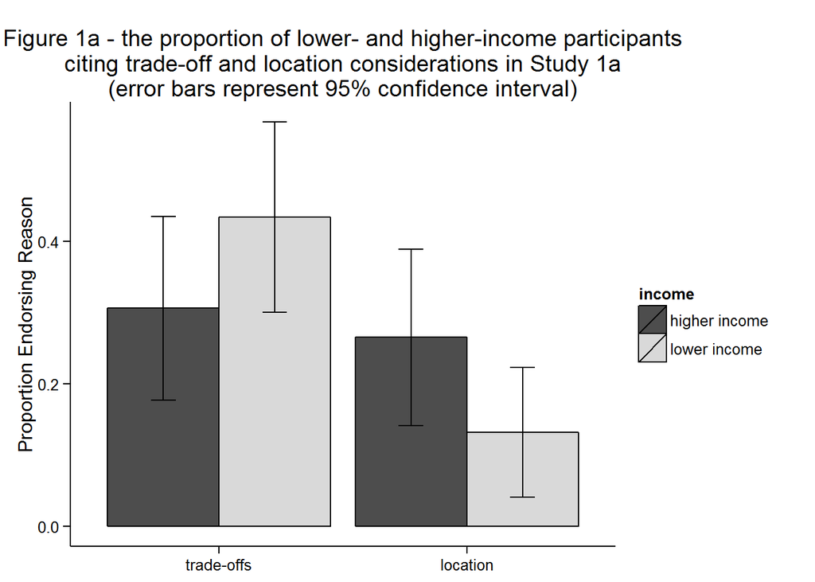

# Study 1b - Consistent Valuations Under Scarcity

In Study 1b, there were 151 participants (mean age = 32.9 years; 76 females, 75 males; median household size = 3 people, median household income = $45000). In Study 1c, there were 604 participants (mean age = 29.9 years; 246 females, 358 males; median household size = 2 people; median household income = $45,000). Study 1d was conducted with a large, representative sample drawn from Survey Sampling International’s panel of U.S respondents. There were 2,015 participants (mean age = 39.1 years; 1,022 females, 993 males; median household size = 3 people; median household income = $55,000). In Study 1b, participants read the beer-on-the-beach scenario and indicated their WTP for the beer. Studies 1c and 1d directly replicated Study 1b. Because WTP was elicited with an open-ended scale, some participants named unreasonably high prices. We describe our exclusion rules for these responses in the next section. These rules were determined before we conducted the significance tests.

```
##   average_age
## 1        32.9
```

```
## Source: local data frame [2 x 2]
##
##   Gender sex_breakdown
## 1      f            76
## 2      m            75
```

```
##   sample.size median.household.income median.household.size
## 1         151                   45000                     3
```

## *Results*

In Study 1b, 2 participants were excluded whose Willing-to-pay (WTP) was more than 3 standard deviations from the mean.

Higher-income participants showed the classic effect, offering a higher price for beer from the resort

```
##   mean.beer   CI.low  CI.high
## 1  6.094595 5.210653 6.978536
```

compared to the grocery store.

```
##   mean.beer   CI.low  CI.high
## 1  4.214286 3.640055 4.788517
```

But lower income participants’ WTP did not differ significantly between beer from the resort

```
##   mean.beer   CI.low  CI.high
## 1  4.444444 3.810319 5.078569
```

and beer from the store.

```
##   mean.beer   CI.low  CI.high
## 1  5.371951 4.351965 6.391937
```

The interaction between income and context was significant F(1,145) = 11.18, p < 0.01, eta squared partial = 0.07.

```
##               Df Sum Sq Mean Sq F value  Pr(>F)
## resort         1    7.3    7.27   1.111 0.29353
## split          1    1.8    1.83   0.280 0.59742
## resort:split   1   73.2   73.16  11.177 0.00105 **
## Residuals    145  949.1    6.55
## ---
## Signif. codes:  0 '***' 0.001 '**' 0.01 '*' 0.05 '.' 0.1 ' ' 1
```

```
##                   eta.sq eta.sq.part
## resort       0.006714223 0.007243346
## split        0.001777891 0.001928269
## resort:split 0.070932460 0.071564466
```

The interaction was also significant when income was treated as a continuous variable beta = 2.27 (the closest I could replicate from the data was 2.67), t(145) = 2.17, p < 0.05.

```
##
## Call:
## lm(formula = beer ~ resort * logses, data = clean_1b)
##
## Residuals:
##    Min     1Q Median     3Q    Max
## -4.688 -1.625 -0.554  1.118 10.080
##
## Coefficients:
##               Estimate Std. Error t value Pr(>|t|)
## (Intercept)     8.8781     3.6730   2.417   0.0169 *
## resort        -11.4355     5.4864  -2.084   0.0389 *
## logses         -0.9095     0.8243  -1.103   0.2717
## resort:logses   2.6781     1.2330   2.172   0.0315 *
## ---
## Signif. codes:  0 '***' 0.001 '**' 0.01 '*' 0.05 '.' 0.1 ' ' 1
##
## Residual standard error: 2.613 on 145 degrees of freedom
## Multiple R-squared:  0.03975,    Adjusted R-squared:  0.01988
## F-statistic: 2.001 on 3 and 145 DF,  p-value: 0.1165
```

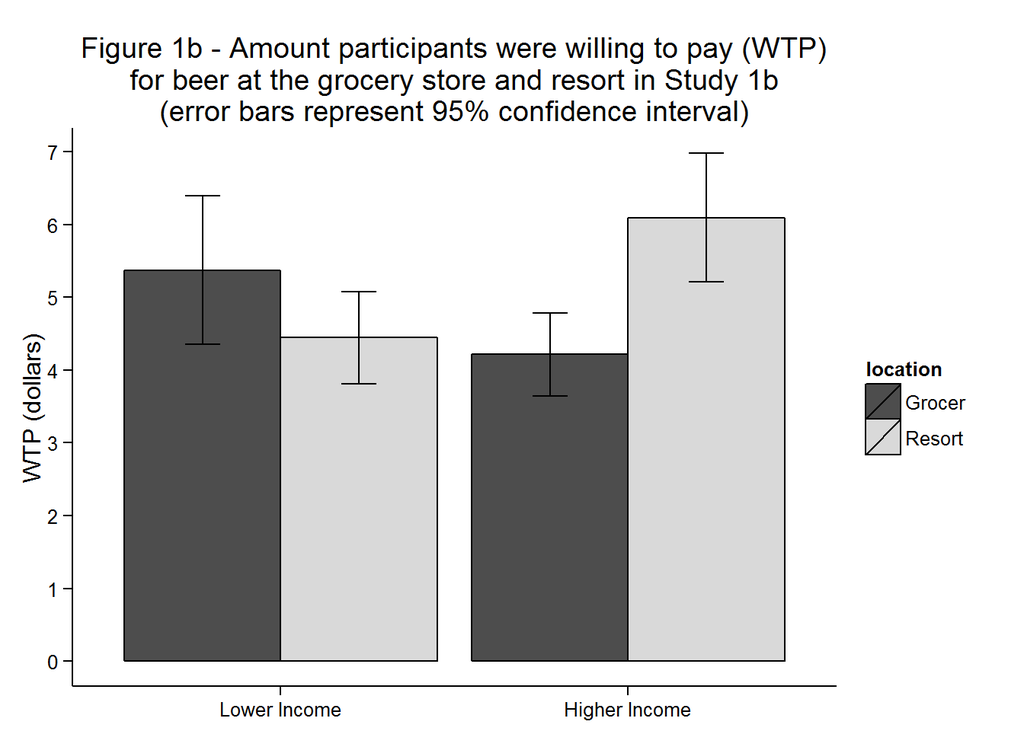

# Study 1c

We replicated the results of 1b with larger samples in studies 1c and 1d. In study 1c, we excluded 2 participants with missing responses, 5 with unreasonably high WTPs (over $100), and 19 additional outliers on WTP, which left 578 participants.

```
##   mean.age
## 1     29.9
```

```
## Source: local data frame [2 x 2]
##
##   gender sex_breakdown
## 1      f           246
## 2      m           358
```

```
##   sample.size
## 1         604
```

```
##   median.household.income median.household.size
## 1                   45000                     2
```

## *Results*

Dividing participants according to a median split on income, we found that higher-income participants offered a higher price for beer from the resort

```
##   mean.beer   ci.low  ci.high
## 1  6.806452 6.337838 7.275065
```

than for beer from the grocery store:

```
##   mean.beer   ci.low  ci.high
## 1  5.413522 5.043781 5.783263
```

Lower-income participants’ WTP did not differ significantly between beer from the resort,

```
##   mean.beer   ci.low  ci.high
## 1   5.89097 5.475666 6.306273
```

and beer from the store.

```
##   mean.beer   ci.low  ci.high
## 1  5.559615 5.063869 6.055361
```

The interaction between income and context was significant, F(1,574) = 5.68, p < 0.05, eta squared partial = 0.01.

```
##               Df Sum Sq Mean Sq F value   Pr(>F)
## resort         1     94   93.53  13.244 0.000298 ***
## split          1     21   20.77   2.940 0.086924 .
## resort:split   1     40   40.10   5.678 0.017508 *
## Residuals    574   4054    7.06
## ---
## Signif. codes:  0 '***' 0.001 '**' 0.01 '*' 0.05 '.' 0.1 ' ' 1
```

```
##                   eta.sq eta.sq.part
## resort       0.024491741 0.024794186
## split        0.004934856 0.005096702
## resort:split 0.009528267 0.009794297
```

The interaction was also significant when income was treated continuously, beta = 1.65 **(the closest I could replicate was 2.03)**, t(574) = 3.27, p < 0.01.

```
##
## Call:
## lm(formula = pay ~ resort * logses, data = clean_1c)
##
## Residuals:
##     Min      1Q  Median      3Q     Max
## -5.9622 -1.6369 -0.5121  1.3600  9.4879
##
## Coefficients:
##               Estimate Std. Error t value Pr(>|t|)
## (Intercept)     6.3459     1.9400   3.271  0.00114 **
## resort         -8.0403     2.7305  -2.945  0.00336 **
## logses         -0.1963     0.4380  -0.448  0.65422
## resort:logses   2.0297     0.6209   3.269  0.00114 **
## ---
## Signif. codes:  0 '***' 0.001 '**' 0.01 '*' 0.05 '.' 0.1 ' ' 1
##
## Residual standard error: 2.637 on 574 degrees of freedom
## Multiple R-squared:  0.05124,    Adjusted R-squared:  0.04629
## F-statistic: 10.33 on 3 and 574 DF,  p-value: 1.24e-06
```

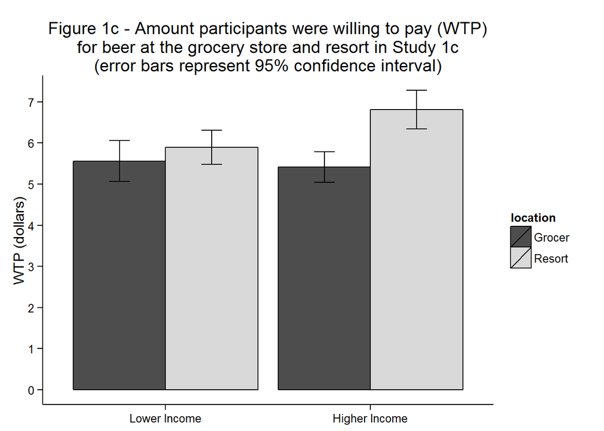

# Study 1d

*note* in our replication, we counted 1,023 females and 992 males - this is a discrepency of +1 female and -1 male.

```
##   mean.age
## 1     39.1
```

```
## Source: local data frame [2 x 2]
##
##   gender sex_breakdown
## 1      f          1023
## 2      m           992
```

```
##   sample.size
## 1        2015
```

```
##   median.household.income median.household.size
## 1                   55000                     3
```

In Study 1d (the nationally representative sample), a large number of participants reported unreasonably high WTPs, and exclusions based on the rules set for the smaller samples in previous studies would have left many unreasonable prices in the data set. We therefore included in our analyses only those participants with a WTP of $20 or less, which seemed like the upper bound of a reasonable price. This set a cutoff price similar to the cutoff price based on the stand deviations in Studies 1b and 1c. After this exclusion and the exclusion of 4 additional participants who were outlines on income, the final sample included 1,898 participants.

## *Results*

Dividing participants according to a median split on eincome, we found that higher-income participants offered a higher price for feer from the resort (M = $6.80, 95% CI [$6.41, $7.18])

```
##   mean.wtp   CI.low  CI.high
## 1 6.795246 6.414316 7.176175
```

than for beer from the grocery store (M = $5.46, 95% CI [$5.13, $5.79]).

```
##   mean.wtp   CI.low  CI.high
## 1 5.459856 5.132609 5.787103
```

Lower-income participants’ WTP did not differ significantly between the resort (M = $6.21, 95% CI [$5.83, $6.60])

```
##   mean.wtp   CI.low  CI.high
## 1 6.210061 5.825056 6.595066
```

and the store (M = %5.71, 95% CI [$5.31, $6.11]).

```
##   mean.wtp   CI.low CI.high
## 1 5.711772 5.313305 6.11024
```

```
##                Df Sum Sq Mean Sq F value   Pr(>F)
## resort          1    389   388.8  22.559 2.19e-06 ***
## split           1     12    12.3   0.716   0.3975
## resort:split    1     83    83.0   4.817   0.0283 *
## Residuals    1894  32647    17.2
## ---
## Signif. codes:  0 '***' 0.001 '**' 0.01 '*' 0.05 '.' 0.1 ' ' 1
```

```
##                    eta.sq  eta.sq.part
## resort       0.0118469662 0.0118798513
## split        0.0003726649 0.0003780493
## resort:split 0.0025058998 0.0025366162
```

This interaction was marginally significant when income was treated continuously, beta = 0.50 **(the closest I could replicate was 0.93)**, t(1894) = 1.85, p < 0.07.

```
##
## Call:
## lm(formula = wtp ~ resort * logses, data = clean_1d)
##
## Residuals:
##     Min      1Q  Median      3Q     Max
## -6.8978 -2.5522 -0.7078  1.4564 14.4821
##
## Coefficients:
##               Estimate Std. Error t value Pr(>|t|)
## (Intercept)     6.3053     1.5838   3.981 7.12e-05 ***
## resort         -3.2483     2.2594  -1.438   0.1507
## logses         -0.1615     0.3535  -0.457   0.6478
## resort:logses   0.9331     0.5052   1.847   0.0649 .
## ---
## Signif. codes:  0 '***' 0.001 '**' 0.01 '*' 0.05 '.' 0.1 ' ' 1
##
## Residual standard error: 4.153 on 1894 degrees of freedom
## Multiple R-squared:  0.01422,    Adjusted R-squared:  0.01266
## F-statistic:  9.11 on 3 and 1894 DF,  p-value: 5.5e-06
```

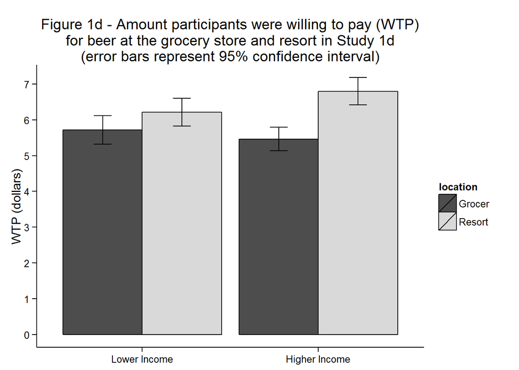

The beer-on-the-beach scenario provides a canonical example of the difficulty people have in translating utility into value. People have a sense of how much they would enjoy the beer, but they have difficulty representing this enjoyment with a price. However, under conditions of scarcity, people base their price not merely on anticipated enjoyment, but also on anticipated trade-offs, and those are more consistent guides for valuation. Could scarcity also lead to more consistent baluation of a dollar itself? The next set of studies addressed this question.

# Study 2a - Proportional Versus Trade-Off Thinking

```
##   mean.age
## 1     30.7
```

```
## Source: local data frame [2 x 2]
##
##   V4 sex_breakdown
## 1  f            96
## 2  m           142
```

```
##   sample.size
## 1         240
```

```
##   median.household.income median.household.size
## 1                   45000                     2
```

```
##   sample.size median.ses
## 1         238   25980.76
```

## *Results*

One participant was excluded as an outlier on income.

We conducted binary logistic regressions to comepare the frequency with which participants cited each of the two considerations of interest (trade-offs vs proportional discount) as a function of income. Higher-income participants were more likely than lower-income participants to use proportional thinking, beta = 0.87, Wald-test chi square (1, N = 237) = 4.02, p < 0.05.

```
##
## Call:
## glm(formula = context ~ lgses, family = "binomial", data = clean_2a)
##
## Deviance Residuals:
##     Min       1Q   Median       3Q      Max
## -1.3592  -1.1498  -0.8601   1.1650   1.5669
##
## Coefficients:
##             Estimate Std. Error z value Pr(>|z|)
## (Intercept)  -3.9050     1.9242  -2.029   0.0424 *
## lgses         0.8739     0.4358   2.005   0.0449 *
## ---
## Signif. codes:  0 '***' 0.001 '**' 0.01 '*' 0.05 '.' 0.1 ' ' 1
##
## (Dispersion parameter for binomial family taken to be 1)
##
##     Null deviance: 328.34  on 236  degrees of freedom
## Residual deviance: 324.19  on 235  degrees of freedom
## AIC: 328.19
##
## Number of Fisher Scoring iterations: 4
```

```
## Wald test:
## ----------
##
## Chi-squared test:
## X2 = 4.0, df = 1, P(> X2) = 0.045
```

but lower-income participants were more likely than higher-income participants to use trade-off thinking, beta = -0.96, Wald-test chi square (1, N = 237) = 4.69, p < 0.05.

```
##
## Call:
## glm(formula = tradeoff ~ lgses, family = "binomial", data = clean_2a)
##
## Deviance Residuals:
##     Min       1Q   Median       3Q      Max
## -1.2620  -0.8973  -0.8292   1.3924   1.7262
##
## Coefficients:
##             Estimate Std. Error z value Pr(>|z|)
## (Intercept)   3.5294     1.9498   1.810   0.0703 .
## lgses        -0.9631     0.4448  -2.165   0.0304 *
## ---
## Signif. codes:  0 '***' 0.001 '**' 0.01 '*' 0.05 '.' 0.1 ' ' 1
##
## (Dispersion parameter for binomial family taken to be 1)
##
##     Null deviance: 301.71  on 236  degrees of freedom
## Residual deviance: 296.97  on 235  degrees of freedom
## AIC: 300.97
##
## Number of Fisher Scoring iterations: 4
```

```
## Wald test:
## ----------
##
## Chi-squared test:
## X2 = 4.7, df = 1, P(> X2) = 0.03
```

This again suggests that scarcity leads people to generate their own comparison standards, and Studies 2b through 2d tested whether this leads to more consistent preferences.

# Study 2b - Valuing Discounts

In study 2b there were 705 participants (mean age = 30.0 years; 290 females, 415 males; median household size = 3 people; median household income = $45,000). The participants in Study 2c were the same participants as in Study 1d (and analyses were limited to the same participants, but including all participants did not change the results). Note that participants completed Studies 1d and 2c in a counterbalanced order. Participants in Studies 2b and 2c responded to the same scenario as did participants in Study 2a, but they stated whether they would travel for the discount.

## *Results*

Confirming earlier findings, these analyses revealed that higher-income participants were more willing to travel when the discount was proportionally larger (i.e., the tablet cost less): Specifically, 86%, 75%, and 58% would travel when the tablet cost $300, $500, and $1,000 respectively.

```
##   fivehundred_go
## 1       85.95041
```

```
##   fivehundred_go
## 1        75.4386
```

```
##   onethousand_go
## 1       58.40708
```

Lower-income participants were less sensitive to the proportional size of the discount: The corresponding percentages of lower-income participants willing to travel were 78%, 67%, and 67%.

```
##   fivehundred_go
## 1       77.77778
```

```
##   fivehundred_go
## 1       67.22689
```

```
##   onethousand_go
## 1       66.94915
```

```
##
## Call:
## glm(formula = go ~ split * cond, family = "binomial", data = clean_2b)
##
## Deviance Residuals:
##     Min       1Q   Median       3Q      Max
## -1.9907  -1.3297   0.7419   0.8305   1.0324
##
## Coefficients:
##             Estimate Std. Error z value Pr(>|z|)
## (Intercept)   1.1496     0.1947   5.904 3.55e-09 ***
## split         0.6835     0.3015   2.267   0.0234 *
## cond         -0.2624     0.1447  -1.814   0.0697 .
## split:cond   -0.4786     0.2157  -2.219   0.0265 *
## ---
## Signif. codes:  0 '***' 0.001 '**' 0.01 '*' 0.05 '.' 0.1 ' ' 1
##
## (Dispersion parameter for binomial family taken to be 1)
##
##     Null deviance: 831.45  on 701  degrees of freedom
## Residual deviance: 804.17  on 698  degrees of freedom
## AIC: 812.17
##
## Number of Fisher Scoring iterations: 4
```

```
## Wald test:
## ----------
##
## Chi-squared test:
## X2 = 4.9, df = 1, P(> X2) = 0.026
```

and was marginally significant when income was treated continuously, beta = -0.57, Wald-test chi square(1, N - 702) = 3.32, p < 0.07.

```
##
## Call:
## glm(formula = go ~ logses * cond, family = "binomial", data = clean_2b)
##
## Deviance Residuals:
##     Min       1Q   Median       3Q      Max
## -2.0085  -1.3450   0.6908   0.8178   1.0655
##
## Coefficients:
##             Estimate Std. Error z value Pr(>|z|)
## (Intercept)  -1.8090     1.8563  -0.974   0.3298
## logses        0.7472     0.4244   1.760   0.0783 .
## cond          2.0248     1.3806   1.467   0.1425
## logses:cond  -0.5729     0.3147  -1.821   0.0686 .
## ---
## Signif. codes:  0 '***' 0.001 '**' 0.01 '*' 0.05 '.' 0.1 ' ' 1
##
## (Dispersion parameter for binomial family taken to be 1)
##
##     Null deviance: 831.45  on 701  degrees of freedom
## Residual deviance: 806.28  on 698  degrees of freedom
## AIC: 814.28
##
## Number of Fisher Scoring iterations: 4
```

```
## Wald test:
## ----------
##
## Chi-squared test:
## X2 = 3.3, df = 1, P(> X2) = 0.069
```

### Study 2c

Five participants were excluded for missing responses in Study 2c, so 1,893 participants were included in the analyses.

Analyses based to a median split on income revealed a more muted trend than in the previous study. Among higher-income participants, 71%, 67%, and 51% were willing to travel when the tablet cost $300, $500, and $1,000, respectively;

```
##   threehundred_go
## 1        71.29909
```

```
##   fivehundred_go
## 1       67.34007
```

```
##   onethousand_go
## 1       51.14754
```

among lower-income participants, the corresponding percentages were 70%, 69%, and 55%.

```
##   threehundred_go
## 1        70.27027
```

```
##   fivehundred_go
## 1       68.73156
```

```
##   onethousand_go
## 1       55.38462
```

When income was treated continuously, the interaction between income and context was clear, beta = -0.39, Wald-test chi square(1, N = 1,893) = 6.13, p < 0.05.

```
##
## Call:
## glm(formula = go ~ logses * webercond, family = "binomial", data = clean_2c)
##
## Deviance Residuals:
##     Min       1Q   Median       3Q      Max
## -1.6561  -1.2955   0.8009   0.9471   1.2669
##
## Coefficients:
##                  Estimate Std. Error z value Pr(>|z|)
## (Intercept)        0.3493     0.9543   0.366   0.7144
## logses             0.1409     0.2130   0.662   0.5082
## webercond          1.3663     0.7110   1.922   0.0547 .
## logses:webercond  -0.3932     0.1588  -2.476   0.0133 *
## ---
## Signif. codes:  0 '***' 0.001 '**' 0.01 '*' 0.05 '.' 0.1 ' ' 1
##
## (Dispersion parameter for binomial family taken to be 1)
##
##     Null deviance: 2472.1  on 1892  degrees of freedom
## Residual deviance: 2419.1  on 1889  degrees of freedom
## AIC: 2427.1
##
## Number of Fisher Scoring iterations: 4
```

# Study 6

> In Study 6, 74 participants (mean age = 32.0 years; 46 females, 28 males) were…

```
## 'data.frame':    74 obs. of  4 variables:
##  $ Subject  : int  3 5 6 8 9 10 11 13 16 17 ...
##  $ Age      : int  39 39 31 21 28 41 34 26 42 31 ...
##  $ Gender   : Factor w/ 2 levels "f","m": 2 1 2 1 2 2 1 1 1 2 ...
##  $ Ethnicity: Factor w/ 15 levels "African-American",..: 4 14 14 1 5 15 14 13 14 15 ...
```

```
## [1] NA
```